# SNAG_DSI Summary

Daniela Cossio

1/30/2023

# Overview

This is the analysis of white matter dsi studio connectometry for Maze and Loop

# Methods

##### **Participants**

- Total number of scans = 120 (males and females )
  - Total scans used in analysis= 118 *Exclude subs 329 and 372 from analyses

##### **Scan parameters**

- Locations from UCSB and UCI

##### **QSIprep**

- Version used: 0.16.0RC3
- The following parameters were used
  - dwi_denoise_window **5**
  - hmc_model **3dSHORE**
  - hmc-transform **Rigid**
  - shoreline_iters **2**

### **DSI Studio**

*Version and tags used* **chen-2022-07-31** A diffusion spectrum imaging scheme was used, and a total of 128 diffusion sampling were acquired. The maximum b-value was 4990 s/mm². The in-plane resolution was 1.8 mm. The slice thickness was 1.8 mm. The accuracy of b-table orientation was examined by comparing fiber orientations with those of a population-averaged template (Yeh et al. Neuroimage, 2018). The b-table was flipped by .012fy. The diffusion data were reconstructed in the MNI space using q-space diffeomorphic reconstruction (Yeh et al., Neuroimage, 58(1):91-9, 2011) to obtain the spin distribution function (Yeh et al., IEEE TMI, ;29(9):1626-35, 2010). A diffusion sampling length ratio of 1.25 was used. The output resolution in diffeomorphic reconstruction was 1.8 mm isotropic. The tensor metrics were calculated using DWI with b-value lower than 1750 s/mm². The quantitative anisotropy was extracted as the local connectome fingerprint (LCF, Yeh et al. PLoS Comput Biol 12(11): e1005203) and used in the connectometry analysis.

#### Connectometry analysis

Diffusion MRI connectometry (Yeh et al. NeuroImage 125 (2016): 162-171) was used to derive the correlational tractography that has QA, MD, AD, and RD correlated with Maze Accuracy and Loop variables. A nonparametric Spearman partial correlation was used to derive the correlation, and the effect of sex, age_scan_years, and repo_status was removed using a multiple regression model. The total number of subjects varied on analysis (See Analyses and Final sample sizes above). A T-score threshold of 2.5 was assigned and tracked using a deterministic fiber tracking algorithm (Yeh et al. PLoS ONE 8(11): e80713, 2013) to obtain correlational tractography. A seeding region was placed at whole brain (39,49,29) . The tracks were filtered by topology-informed pruning (Yeh et al. Neurotherapeutics, 16(1), 52-58, 2019) with 4 iteration(s). A length threshold of 25 voxel distance was used to select tracks. To estimate the false discovery rate, a total of 4000 randomized permutations were applied to the group label to obtain the null distribution of the track length.

###### **Parameters**

- T-threshold = 2.5
- Length = 25
- Permutation = 4,000
- pruning 4
- non normalized QA

#### **Analyses and Final sample sizes**

##### **Exclusions**

- 347 was excluded due to low quality out liar in DSI

##### Maze Accuracy and Path Efficiency

###### N

- All subjects = 82
- Men = 22
- Women = 60
- Stage
  - Pre = 23
  - Peri = 20
  - Post = 17

##### Loop: Position Error, Degree Error, Angular Error

###### Rad 3

- some subjects removed becuase they did not have rad3 score
- All subjects = 38
- Men = 14
- Women = 24
- Stage
  - Pre = 10
  - Peri = 7
  - Post = 7

# Maze Accuracy

#### DSI output

## QA

### Summary of results

There were both positive and negative correlations between QA and maze performance when all subjects were included in the analysis. When men were analyzed separately, men displayed more negatively associated correlations between QA and maze performance. Women displayed tracts with predominantly positive correlations between QA and performance. When split by menopause stagge, Pre and post displayed both positive and negative correlations while peri displayed only positive correlations with performance.

### All subjects

#### Positive ( FDR= 0.043228)

| Tract Name | number of tracts | mean length(mm) | diameter(mm) | volume(mm^3) |
| --- | --- | --- | --- | --- |
| Corpus_Callosum_Tapetum | 164 | 57.5732 | 6.71347 | 2038 |
| Corpus_Callosum_Forceps_Minor | 25 | 51.92 | 4.31996 | 761 |
| Corpus_Callosum_Forceps_Major | 22 | 51.7273 | 4.37326 | 777 |
| Cingulum_Parolfactory_R | 19 | 51.6842 | 3.00273 | 366 |
| Cingulum_Frontal_Parietal_L | 4 | 52 | 1.96066 | 157 |

#### Neg ( FDR= 0.122807)

| Tract Name | number of tracts | mean length(mm) | diameter(mm) | volume(mm^3) |
| --- | --- | --- | --- | --- |
| Superior_Longitudinal_Fasciculus2_R | 95 | 56.5053 | 6.13252 | 1669 |
| Corpus_Callosum_Forceps_Major | 88 | 54.1364 | 5.88189 | 1471 |
| Corpus_Callosum_Tapetum | 73 | 52.5205 | 6.26296 | 1618 |
| Cerebellum_L | 66 | 52.8182 | 5.28801 | 1160 |
| Cingulum_Frontal_Parietal_L | 18 | 52.8889 | 2.63768 | 289 |
| Corpus_Callosum_Forceps_Minor | 11 | 53.4545 | 2.54066 | 271 |
| Corpus_Callosum_Body | 10 | 51.4 | 2.73512 | 302 |
| Cingulum_Frontal_Parahippocampal_L | 5 | 53.6 | 1.82363 | 140 |
| Middle_Cerebellar_Peduncle | 5 | 51.6 | 2.39777 | 233 |

#### Figures

[figure not shown]

### Men

#### Positive Corrs (FDR = 0.018519)

| Tract Name | number of tracts | mean length(mm) | diameter(mm) | volume(mm^3) |
| --- | --- | --- | --- | --- |
| Negative Correlation | 3051 | 56.706 | 25.9521 | 29996 |
| Corpus_Callosum_Tapetum | 38 | 51.8947 | 4.63073 | 874 |
| Corpus_Callosum_Body | 2 | 50 | 1.34462 | 71 |

#### Neg Corrs (FDR = 0.001161)

| Tract Name | number of tracts | mean length(mm) | diameter(mm) | volume(mm^3) |
| --- | --- | --- | --- | --- |
| Cerebellum_L | 1024 | 57.0742 | 14.1861 | 9021 |
| Middle_Cerebellar_Peduncle | 936 | 58.109 | 12.1046 | 6687 |
| Cerebellum_R | 340 | 54.8059 | 11.0575 | 5263 |
| Fornix_R | 207 | 56.029 | 5.50588 | 1334 |
| Corpus_Callosum_Body | 139 | 53.9712 | 7.94987 | 2679 |
| Corpus_Callosum_Tapetum | 86 | 54.4186 | 6.54345 | 1830 |
| Corpus_Callosum_Forceps_Major | 86 | 55 | 6.76172 | 1975 |
| Inferior_Fronto_Occipital_Fasciculus_L | 51 | 54.2745 | 4.50209 | 864 |
| Inferior_Cerebellar_Peduncle_R | 36 | 58.7222 | 4.55522 | 957 |
| Inferior_Longitudinal_Fasciculus_L | 33 | 60.1818 | 4.03615 | 770 |

### Women

#### Positive Corrs (FDR = 0.000263)

| Tract Name | number of tracts | mean length(mm) | diameter(mm) | volume(mm^3) |
| --- | --- | --- | --- | --- |
| Corpus_Callosum_Tapetum | 454 | 58.5374 | 7.88027 | 2855 |
| Corpus_Callosum_Forceps_Major | 198 | 57.9596 | 8.40786 | 3218 |
| Cingulum_Frontal_Parietal_L | 169 | 53.4675 | 7.14867 | 2146 |
| Cingulum_Frontal_Parietal_R | 151 | 55.0729 | 6.58747 | 1877 |
| Inferior_Fronto_Occipital_Fasciculus_R | 149 | 58.8188 | 6.25945 | 1810 |
| Uncinate_Fasciculus_R | 132 | 60.9848 | 5.96106 | 1702 |
| Middle_Cerebellar_Peduncle | 130 | 54.0769 | 6.16263 | 1613 |
| Corticospinal_Tract_L | 98 | 53.898 | 7.61388 | 2454 |
| Cingulum_Parolfactory_R | 94 | 57.9149 | 5.0565 | 1163 |
| Middle_Longitudinal_Fasciculus_R | 76 | 51.7368 | 4.47577 | 814 |
| Cingulum_Frontal_Parahippocampal_L | 51 | 52.1177 | 5.31424 | 1156 |
| Superior_Longitudinal_Fasciculus2_R | 49 | 54.5714 | 4.16638 | 744 |
| Superior_Longitudinal_Fasciculus1_L | 40 | 51.5 | 4.43895 | 797 |
| Cerebellum_L | 40 | 51.65 | 4.27395 | 741 |
| Corticospinal_Tract_R | 38 | 55.8421 | 3.62712 | 577 |
| Corpus_Callosum_Forceps_Minor | 29 | 53.7931 | 4.3542 | 801 |
| Corticostriatal_Tract_Superior_L | 25 | 51.52 | 3.79904 | 584 |

#### Neg Corrs (FDR = 0.002809)

| Tract Name | number of tracts | mean length(mm) | diameter(mm) | volume(mm^3) |
| --- | --- | --- | --- | --- |
| Corpus_Callosum_Tapetum | 142 | 53.5493 | 6.60176 | 1833 |
| Corpus_Callosum_Forceps_Major | 135 | 54.8593 | 6.0537 | 1579 |
| Corpus_Callosum_Body | 98 | 52.4082 | 5.89418 | 1430 |
| Corpus_Callosum_Forceps_Minor | 76 | 51.8684 | 5.68154 | 1315 |
| Cingulum_Frontal_Parietal_L | 75 | 54.08 | 4.71935 | 946 |
| Cingulum_Parolfactory_R | 32 | 55.8125 | 3.56465 | 557 |
| Cingulum_Frontal_Parahippocampal_L | 24 | 57.5 | 2.99467 | 405 |
| Corticospinal_Tract_L | 17 | 60.4706 | 3.21204 | 490 |
| Superior_Longitudinal_Fasciculus2_R | 10 | 58 | 2.72798 | 339 |

#### Figures

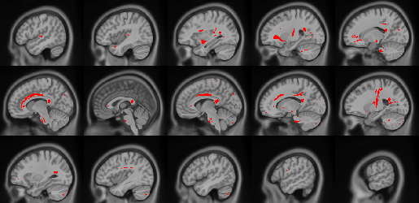

Positive Correlations between QA and maze accuracy in women.

### pre

#### Positive Corrs (FDR = 0.044369)

| Tract Name | number of tracts | mean length(mm) | diameter(mm) | volume(mm^3) |
| --- | --- | --- | --- | --- |
| Cerebellum_L | 187 | 55.4332 | 7.16168 | 2233 |
| Cingulum_Frontal_Parietal_R | 92 | 55.2826 | 5.08343 | 1122 |
| Fornix_L | 57 | 55.5789 | 4.93244 | 1062 |
| Superior_Longitudinal_Fasciculus1_L | 23 | 51.4783 | 3.02104 | 369 |
| Middle_Cerebellar_Peduncle | 13 | 54.4615 | 3.4258 | 502 |
| Cingulum_Parolfactory_R | 6 | 62.3333 | 2.42965 | 289 |
| Corpus_Callosum_Tapetum | 5 | 54.4 | 1.71045 | 125 |
| Corpus_Callosum_Forceps_Major | 5 | 52.8 | 1.70817 | 121 |

#### Neg Corrs (FDR = 0.011788)

| Tract Name | number of tracts | mean length(mm) | diameter(mm) | volume(mm^3) |
| --- | --- | --- | --- | --- |
| Corpus_Callosum_Forceps_Minor | 488 | 55.5902 | 8.95216 | 3499 |
| Corpus_Callosum_Forceps_Major | 276 | 58.6956 | 6.83875 | 2156 |
| Cingulum_Frontal_Parietal_L | 124 | 55.4677 | 5.24401 | 1198 |
| Corpus_Callosum_Tapetum | 111 | 54.6486 | 6.39264 | 1754 |
| Cingulum_Parolfactory_R | 75 | 55.3867 | 4.2399 | 782 |
| Corticospinal_Tract_R | 52 | 57.0385 | 4.4447 | 885 |
| Corpus_Callosum_Body | 42 | 52.5714 | 4.32403 | 772 |
| Cingulum_Frontal_Parahippocampal_L | 34 | 54.7647 | 3.60182 | 558 |
| Cingulum_Parolfactory_L | 27 | 52.6667 | 4.16629 | 718 |
| Uncinate_Fasciculus_R | 25 | 56.4 | 3.44922 | 527 |
| NA | NA | NA | NA | NA |

### peri

#### Positive Corrs (FDR = 0.000231)

| Tract Name | number of tracts | mean length(mm) | diameter(mm) | volume(mm^3) |
| --- | --- | --- | --- | --- |
| Corticospinal_Tract_L | 863 | 57.1031 | 11.1693 | 5595 |
| Corticospinal_Tract_R | 661 | 57.1528 | 9.86907 | 4372 |
| Corpus_Callosum_Forceps_Minor | 444 | 59.3964 | 10.6156 | 5257 |
| Cingulum_Frontal_Parietal_L | 143 | 53.8462 | 6.18921 | 1620 |
| Superior_Longitudinal_Fasciculus2_R | 106 | 54.1132 | 5.56457 | 1316 |
| Medial_Lemniscus_R | 86 | 55.9302 | 5.9344 | 1547 |
| Cingulum_Parolfactory_R | 78 | 60.2051 | 4.52456 | 968 |
| Cingulum_Frontal_Parahippocampal_L | 44 | 53.0455 | 4.53546 | 857 |
| Corpus_Callosum_Forceps_Major | 43 | 53.7674 | 4.1148 | 715 |
| Medial_Lemniscus_L | 39 | 53.8462 | 4.6869 | 929 |

#### Neg Corrs (FDR = 1.000000)

No Significant Findings

### post

#### Positive Corrs (FDR = 0.000418)

| Tract Name | number of tracts | mean length(mm) | diameter(mm) | volume(mm^3) |
| --- | --- | --- | --- | --- |
| Corpus_Callosum_Forceps_Major | 532 | 57.594 | 9.34469 | 3950 |
| Corpus_Callosum_Tapetum | 531 | 55.1224 | 11.0195 | 5257 |
| Inferior_Longitudinal_Fasciculus_L | 88 | 58.4545 | 5.95305 | 1627 |
| Corticospinal_Tract_R | 80 | 55.925 | 4.82603 | 1023 |
| Corticospinal_Tract_L | 76 | 56.2368 | 5.44395 | 1309 |
| Inferior_Fronto_Occipital_Fasciculus_L | 43 | 55.3023 | 4.49092 | 876 |
| Cingulum_Frontal_Parietal_R | 37 | 52.5405 | 3.9382 | 640 |
| Cerebellum_L | 29 | 52.4138 | 5.18803 | 1108 |
| Corticopontine_Tract_Occipital_L | 26 | 57.9231 | 3.6648 | 611 |
| Corticostriatal_Tract_Posterior_L | 25 | 53.84 | 4.12924 | 721 |

#### Neg Corrs (FDR = 0.015152)

| Tract Name | number of tracts | mean length(mm) | diameter(mm) | volume(mm^3) |
| --- | --- | --- | --- | --- |
| Cerebellum_R | 32 | 56.875 | 5.31736 | 1263 |
| Cingulum_Parolfactory_R | 8 | 55.75 | 1.64856 | 119 |
| Arcuate_Fasciculus_L | 3 | 52 | 1.41697 | 82 |
| Corpus_Callosum_Forceps_Major | 2 | 52 | 1.46789 | 88 |

## MD

### Summary of results

DSI was run on all subjects, with sex and age listed as covariates. There were positive correlations between MD values in the Fornix (L&R) and performance. Using a sex stratified apporoach we viewed the relationship between white matter and performance in men and women separately. Men, displayed a majortiy of positive correlations between tracts with MD and accuracy. Specifically in regions associated with navigation such as the fornix (L & R). Women, displayed a majortiy of negative correlations between tracts with MD and accuracy. Specifically in regions associated with navigation such as the fornix (L & R), and cerebelllum. We then investigated the relationship of white matter and performance when splitting by menopause stage. Pre menopause women displayed a majortiy of negative correlations between tracts with MD and accuracy in the fornix(L&R) and corpus callosum. Peri menopause women displayed a majority of positive correlations between tracts with MD and accuracy in the fornix(L&R) cerebellum and cingulum. Post Menopause displayed both positive and negative relationships between MD and performance. The majority of tracts with positive correlations were in the fornix, while a majority of the negative correlations were found in tracts in the parietal cortex and cerebellum.

### All subjects

#### Positive Corrs (FDR = 0.124661)

| Tract Name | number of tracts | mean length(mm) | diameter(mm) | volume(mm^3) |
| --- | --- | --- | --- | --- |
| Fornix_R | 402 | 54.3731 | 7.84916 | 2631 |
| Fornix_L | 272 | 54.5515 | 7.16903 | 2202 |
| Thalamic_Radiation_Superior_L | 1 | 58 | 1.22179 | 68 |

#### Negative Corrs (FDR = 1.000000)

No significant findings

### Men

#### Positive Corrs (FDR = 0.012068)

| Tract Name | number of tracts | mean length(mm) | diameter(mm) | volume(mm^3) |
| --- | --- | --- | --- | --- |
| Fornix_R | 957 | 55.3521 | 9.27769 | 3742 |
| Fornix_L | 473 | 56.1818 | 8.32892 | 3061 |
| Thalamic_Radiation_Superior_L | 94 | 58.2979 | 5.05501 | 1170 |
| Superior_Longitudinal_Fasciculus2_R | 89 | 57.3483 | 5.31629 | 1273 |
| Arcuate_Fasciculus_R | 52 | 56 | 5.30758 | 1239 |
| Thalamic_Radiation_Superior_R | 28 | 55.7857 | 3.84278 | 647 |

#### Neg Corrs (FDR = 0.075269)

| Tract Name | number of tracts | mean length(mm) | diameter(mm) | volume(mm^3) |
| --- | --- | --- | --- | --- |
| Cerebellum_L | 43 | 54.3256 | 4.00388 | 684 |

### Women

#### Positive Corrs (FDR = 0.071429)

| Tract Name | number of tracts | mean length(mm) | diameter(mm) | volume(mm^3) |
| --- | --- | --- | --- | --- |
| Negative Correlation | 800 | 55.4 | 12.7606 | 7085 |
| Fornix_R | 8 | 53.5 | 2.18169 | 200 |
| Fornix_L | 2 | 52 | 1.54113 | 97 |

#### Neg Corrs (FDR = 0.061328)

| Tract Name | number of tracts | mean length(mm) | diameter(mm) | volume(mm^3) |
| --- | --- | --- | --- | --- |
| Fornix_L | 319 | 56.9843 | 7.30304 | 2387 |
| Cerebellum_L | 131 | 52.8244 | 5.16782 | 1108 |
| Fornix_R | 126 | 55.7778 | 4.78015 | 1001 |
| Cingulum_Frontal_Parietal_L | 39 | 58.4615 | 3.37175 | 522 |
| Thalamic_Radiation_Anterior_L | 19 | 53.4737 | 2.78608 | 326 |
| Cerebellum_R | 13 | 53.3846 | 2.64351 | 293 |

### pre

#### Positive Corrs (FDR = 1.000000)

No significant findings

#### Neg Corrs (FDR = 0.002473)

| Tract Name | number of tracts | mean length(mm) | diameter(mm) | volume(mm^3) |
| --- | --- | --- | --- | --- |
| Fornix_L | 1210 | 58.0314 | 10.1267 | 4674 |
| Fornix_R | 131 | 54.9924 | 5.98866 | 1549 |
| Corpus_Callosum_Forceps_Major | 72 | 55.1389 | 5.76243 | 1438 |
| Cerebellum_L | 60 | 53.5 | 4.57375 | 879 |
| Thalamic_Radiation_Superior_L | 54 | 58 | 4.71337 | 1012 |
| Corpus_Callosum_Tapetum | 49 | 54.898 | 4.45047 | 854 |
| Corpus_Callosum_Body | 26 | 52 | 3.53723 | 511 |

### peri

#### Positive Corrs (FDR = 0.000106)

| Tract Name | number of tracts | mean length(mm) | diameter(mm) | volume(mm^3) |
| --- | --- | --- | --- | --- |
| Fornix_L | 1277 | 59.8168 | 9.05144 | 3849 |
| Fornix_R | 531 | 57.7439 | 7.73441 | 2713 |
| Cerebellum_L | 488 | 53.291 | 8.99837 | 3389 |
| Cerebellum_R | 230 | 55.1304 | 8.90812 | 3436 |
| Cingulum_Frontal_Parietal_L | 203 | 56.9458 | 5.33924 | 1275 |
| Thalamic_Radiation_Superior_L | 121 | 57.5207 | 5.92322 | 1585 |
| Corpus_Callosum_Forceps_Major | 82 | 53.6341 | 4.98072 | 1045 |
| Cingulum_Frontal_Parahippocampal_L | 42 | 58.6667 | 4.14855 | 793 |

#### Neg Corrs (FDR = 0.351351)

No significant findings

### post

#### Positive Corrs (FDR = 0.000106)

| Tract Name | number of tracts | mean length(mm) | diameter(mm) | volume(mm^3) |
| --- | --- | --- | --- | --- |
| Fornix_R | 670 | 55.5164 | 8.05206 | 2827 |
| Fornix_L | 348 | 54.6207 | 6.29878 | 1702 |
| Thalamic_Radiation_Superior_L | 32 | 54.0625 | 3.75909 | 600 |
| Corpus_Callosum_Tapetum | 13 | 52.1539 | 3.13274 | 402 |

#### Neg Corrs (FDR = 0.351351)

| Tract Name | number of tracts | mean length(mm) | diameter(mm) | volume(mm^3) |
| --- | --- | --- | --- | --- |
| Cerebellum_R | 256 | 52.5547 | 8.66343 | 3098 |
| Superior_Longitudinal_Fasciculus2_R | 246 | 57.0163 | 7.45086 | 2486 |
| Cerebellum_L | 203 | 52.7882 | 7.8763 | 2572 |
| Inferior_Longitudinal_Fasciculus_L | 159 | 56.1384 | 8.01441 | 2832 |
| Arcuate_Fasciculus_L | 109 | 57.8349 | 6.97835 | 2212 |
| Arcuate_Fasciculus_R | 82 | 53.7561 | 6.83777 | 1974 |
| Corticostriatal_Tract_Posterior_R | 71 | 53.0704 | 5.82443 | 1414 |
| Inferior_Fronto_Occipital_Fasciculus_L | 47 | 56.5106 | 4.93974 | 1083 |
| Superior_Longitudinal_Fasciculus2_L | 40 | 54.9 | 5.27545 | 1200 |

## AD

### Summary of results

Only fornix was negatively associated with performance when all subejcts were analyzed. Fornix and thalamic raditions were positively associated with accuracy.Women displayed negative relationships with tracts int he fornix and cingulum and maze acc. Women in the pre menopasual groups showed tracts were negatively correlated with acc in fornix ,and corpus callosum. Peri menopausal women showed that a majority of tracts in the fornix, cingulum, and cerebellum were positively associated with Acc. Post menopasual women showed positive tracts in the fornix and negative tracts in the cerbebellum.

### All subjects

#### Negative Corrs ( FDR = 0.150000)

| Tract Name | number of tracts | mean length(mm) | diameter(mm) | volume(mm^3) |
| --- | --- | --- | --- | --- |
| Fornix_L | 10 | 52.4 | 2.55662 | 269 |

### Men

#### Positive ( FDR= 0.005460)

| Tract Name | number of tracts | mean length(mm) | diameter(mm) | volume(mm^3) |
| --- | --- | --- | --- | --- |
| Fornix_R | 1299 | 54.8637 | 10.0105 | 4318 |
| Fornix_L | 783 | 55.3844 | 9.63245 | 4036 |
| Thalamic_Radiation_Superior_L | 504 | 56.4365 | 8.47809 | 3186 |
| Thalamic_Radiation_Superior_R | 209 | 54.5263 | 6.30793 | 1704 |

#### Neg ( FDR = FDR = 0.004202 )

| Tract Name | number of tracts | mean length(mm) | diameter(mm) | volume(mm^3) |
| --- | --- | --- | --- | --- |
| Cerebellum_L | 122 | 53.9836 | 4.79788 | 976 |

### Women

#### Positive ( FDR= 1.000000 )

No significant findings

#### Neg ( FDR=0.006928 )

| Tract Name | number of tracts | mean length(mm) | diameter(mm) | volume(mm^3) |
| --- | --- | --- | --- | --- |
| Fornix_L | 97 | 54 | 5.16404 | 1131 |
| Cerebellum_L | 70 | 53.4571 | 3.97682 | 664 |
| Corpus_Callosum_Forceps_Major | 59 | 53.0169 | 4.42683 | 816 |
| Cingulum_Frontal_Parietal_L | 13 | 55.6923 | 1.96563 | 169 |
| Fornix_R | 12 | 52.1667 | 2.55756 | 268 |
| Cerebellum_R | 3 | 50 | 1.76979 | 123 |

### pre

#### Positive ( FDR = 1.000000 )

No significant findings

#### Neg ( FDR = 0.000197 )

| Tract Name | number of tracts | mean length(mm) | diameter(mm) | volume(mm^3) |
| --- | --- | --- | --- | --- |
| Fornix_L | 1513 | 57.811 | 10.6532 | 5153 |
| Corpus_Callosum_Forceps_Major | 241 | 54.3485 | 6.98563 | 2083 |
| Thalamic_Radiation_Superior_L | 195 | 56.9231 | 6.87318 | 2112 |
| Fornix_R | 191 | 54.2513 | 6.70401 | 1915 |
| Cerebellum_L | 165 | 53.6485 | 4.59333 | 889 |
| Corpus_Callosum_Tapetum | 52 | 56.7692 | 4.88276 | 1063 |

### peri

#### Positive ( FDR= 0.000282 )

| Tract Name | number of tracts | mean length(mm) | diameter(mm) | volume(mm^3) |
| --- | --- | --- | --- | --- |
| Fornix_L | 465 | 58.0688 | 8.17104 | 3045 |
| Cerebellum_L | 334 | 53.2036 | 8.33074 | 2900 |
| Fornix_R | 219 | 57.8813 | 6.85146 | 2134 |
| Cingulum_Frontal_Parietal_L | 175 | 56.4229 | 5.22109 | 1208 |
| Cerebellum_R | 165 | 54.8364 | 7.78617 | 2611 |
| Thalamic_Radiation_Superior_L | 119 | 56.2521 | 5.85201 | 1513 |
| Corpus_Callosum_Forceps_Major | 38 | 52.4211 | 4.7091 | 913 |
| Cingulum_Frontal_Parahippocampal_L | 29 | 58.8966 | 3.89286 | 701 |

#### Neg ( FDR=0.016393 )

| Tract Name | number of tracts | mean length(mm) | diameter(mm) | volume(mm^3) |
| --- | --- | --- | --- | --- |
| Fornix_R | 35 | 55.7143 | 3.57739 | 560 |

### post

#### Positive ( FDR= 0.000941 )

| Tract Name | number of tracts | mean length(mm) | diameter(mm) | volume(mm^3) |
| --- | --- | --- | --- | --- |
| Fornix_R | 269 | 54.3197 | 6.11444 | 1595 |
| Fornix_L | 196 | 53.5306 | 5.1313 | 1107 |
| Thalamic_Radiation_Superior_L | 45 | 56.0444 | 3.7862 | 631 |

#### Neg ( FDR= 0.001445 )

| Tract Name | number of tracts | mean length(mm) | diameter(mm) | volume(mm^3) |
| --- | --- | --- | --- | --- |
| Cerebellum_L | 141 | 52.2837 | 6.15371 | 1555 |
| Cerebellum_R | 128 | 53.7031 | 6.35049 | 1701 |

## RD

### Summary of results

All subjects analyzed, tracts in the fornix were positively associated with acc. In Men, tracts in the fornix were positvely associated with acc. Women showed tracts in the fornix were negatively associated with acc. Pre menopausal women showed a similar findings to women with negative correlations in tracts in the fornix. Peri menopasual women showed results similar to men, with tracts in the fornix positively associated. Post menopausal women displayed positive and negative associations with a majority of positive tracts located in the fornix and negative tracts in the cerebellum.

### All subjects

#### Positive ( FDR= 0.146417 )

| Tract Name | number of tracts | mean length(mm) | diameter(mm) | volume(mm^3) |
| --- | --- | --- | --- | --- |
| Fornix_R | 424 | 54.2311 | 7.73295 | 2547 |
| Fornix_L | 159 | 53.044 | 6.32374 | 1666 |
| Thalamic_Radiation_Superior_R | 11 | 52 | 2.51341 | 258 |

#### Neg ( FDR= 1.000000)

No significant findings

### Men

#### Positive Corrs (FDR = 0.019254)

| Tract Name | number of tracts | mean length(mm) | diameter(mm) | volume(mm^3) |
| --- | --- | --- | --- | --- |
| Fornix_R | 1152 | 55.7396 | 9.34491 | 3823 |
| Fornix_L | 507 | 56.2209 | 8.34911 | 3078 |
| Thalamic_Radiation_Superior_L | 71 | 59.6338 | 4.74158 | 1053 |
| Thalamic_Radiation_Superior_R | 20 | 54.9 | 3.35728 | 486 |

#### Neg Corrs (FDR = 0.800000)

No Significant Findings

### Women

#### Positive Corrs (FDR = 0.083333)

No Significant Findings

#### Neg Corrs (FDR = 0.074362)

| Tract Name | number of tracts | mean length(mm) | diameter(mm) | volume(mm^3) |
| --- | --- | --- | --- | --- |
| Fornix_L | 280 | 55.8643 | 7.1595 | 2249 |
| Cerebellum_L | 94 | 52.5106 | 4.81963 | 958 |
| Fornix_R | 64 | 54.5 | 4.4352 | 842 |
| Cingulum_Frontal_Parietal_L | 48 | 59.4167 | 2.96771 | 411 |
| Corpus_Callosum_Forceps_Major | 28 | 53.4286 | 3.45531 | 501 |
| Thalamic_Radiation_Anterior_L | 20 | 54.1 | 2.95092 | 370 |
| Corpus_Callosum_Body | 7 | 50.5714 | 2.76655 | 304 |

### pre

#### Positive Corrs (FDR = 1.000000)

No Significant Findings

#### Neg Corrs (FDR = 0.010636)

| Tract Name | number of tracts | mean length(mm) | diameter(mm) | volume(mm^3) |
| --- | --- | --- | --- | --- |
| Fornix_L | 1265 | 58.4553 | 10.1983 | 4775 |
| Fornix_R | 193 | 56.0622 | 6.8383 | 2059 |
| Corpus_Callosum_Forceps_Major | 64 | 56.4062 | 5.0883 | 1147 |
| Corpus_Callosum_Tapetum | 53 | 55.6226 | 4.78681 | 1001 |
| Cerebellum_L | 22 | 52.6364 | 3.51923 | 512 |
| Corpus_Callosum_Body | 17 | 51.4118 | 3.41534 | 471 |

### peri

#### Positive Corrs (FDR = 0.000248)

| Tract Name | number of tracts | mean length(mm) | diameter(mm) | volume(mm^3) |
| --- | --- | --- | --- | --- |
| Fornix_L | 805 | 58.9615 | 7.82847 | 2838 |
| Fornix_R | 322 | 56.9938 | 7.13375 | 2278 |
| Cerebellum_L | 288 | 52.6181 | 7.71377 | 2459 |
| Cerebellum_R | 94 | 55.5957 | 5.86111 | 1500 |
| Thalamic_Radiation_Superior_L | 42 | 58.8095 | 4.08032 | 769 |
| Cingulum_Frontal_Parietal_L | 38 | 57.4211 | 4.03704 | 735 |
| Corpus_Callosum_Forceps_Major | 28 | 55.1429 | 3.38075 | 495 |
| Cingulum_Frontal_Parahippocampal_L | 21 | 62 | 3.37298 | 554 |

### post

#### Positive Corrs (FDR = 0.000777)

| Tract Name | number of tracts | mean length(mm) | diameter(mm) | volume(mm^3) |
| --- | --- | --- | --- | --- |
| Fornix_R | 606 | 55.2706 | 7.80881 | 2647 |
| Fornix_L | 262 | 54.2519 | 5.83353 | 1450 |
| Thalamic_Radiation_Superior_L | 21 | 55.5238 | 3.23369 | 456 |
| Corpus_Callosum_Tapetum | 14 | 52.7143 | 3.32964 | 459 |

#### Neg Corrs (FDR = 0.040343)

| Tract Name | number of tracts | mean length(mm) | diameter(mm) | volume(mm^3) |
| --- | --- | --- | --- | --- |
| Cerebellum_R | 228 | 52.7895 | 8.23841 | 2814 |
| Cerebellum_L | 171 | 52.7251 | 7.92226 | 2599 |
| Corticostriatal_Tract_Posterior_R | 99 | 54.0404 | 6.24446 | 1655 |
| Inferior_Longitudinal_Fasciculus_L | 69 | 55.2464 | 6.37245 | 1762 |
| Corpus_Callosum_Forceps_Major | 56 | 53.8929 | 4.97588 | 1048 |
| Superior_Longitudinal_Fasciculus2_R | 42 | 54.0476 | 4.8122 | 983 |
| Frontal_Aslant_Tract_L | 35 | 59.7714 | 4.38826 | 904 |
| Middle_Longitudinal_Fasciculus_R | 19 | 53.7895 | 4.37874 | 810 |
| Arcuate_Fasciculus_R | 18 | 52.7778 | 3.54186 | 520 |
| Inferior_Fronto_Occipital_Fasciculus_L | 17 | 55.5294 | 3.99483 | 696 |
| Corpus_Callosum_Tapetum | 10 | 57.6 | 3.31786 | 498 |
| Inferior_Fronto_Occipital_Fasciculus_R | 9 | 50.6667 | 2.80457 | 313 |

### peri post combination

#### Positive Corrs (FDR = 0.000994)

| Tract Name | number of tracts | mean length(mm) | diameter(mm) | volume(mm^3) |
| --- | --- | --- | --- | --- |
| Fornix_L | 369 | 55.0406 | 6.07426 | 1595 |
| Fornix_R | 140 | 55.4857 | 6.28062 | 1719 |

#### Neg Corrs (FDR = 0.009259)

| Tract Name | number of tracts | mean length(mm) | diameter(mm) | volume(mm^3) |
| --- | --- | --- | --- | --- |
| Positive Correlation | 510 | 55.1529 | 8.82166 | 3371 |
| Cerebellum_R | 55 | 52.2182 | 4.94532 | 1003 |

# Loop Position Error Rad3

## QA

### Summary of results

QA values in several tracts were negatively correlated with Loop Position Error performance in a circle with a 3 m radius. When men and women were analyzed separately, there were different relationships observed. The majority of tracts in men were positively correlated with Position Error and QA values.Suggesting that better QA and white matter integrity is associated with increased Position error. The majority of tracts in women were negatively correlated with QA values and Position error, with a few that were positive. This suggests that in women, white matter integrity is associated with lower position error scores. When splitting by meno pause stage, Pre menopausal women displayed both negative and positive relationships between QA and position error. Peri menopausal women displayed negative correlations between QA and position error. .

### All subjects

#### Positive Corrs (FDR = 0.077333)

| Tract Name | number of tracts | mean length(mm) | diameter(mm) | volume(mm^3) |
| --- | --- | --- | --- | --- |
| Corpus_Callosum_Forceps_Minor | 182 | 53.8249 | 8.31103 | 2920 |
| Cerebellum_L | 49 | 52.8296 | 4.37448 | 794 |

#### Neg Corrs (FDR = 0.001964)

| Tract Name | number of tracts | mean length(mm) | diameter(mm) | volume(mm^3) |
| --- | --- | --- | --- | --- |
| Corticospinal_Tract_R | 490 | 55.2333 | 9.66114 | 4049 |
| Arcuate_Fasciculus_R | 258 | 52.8135 | 5.58318 | 1293 |
| Medial_Lemniscus_R | 142 | 56.1227 | 6.02296 | 1599 |
| Corpus_Callosum_Tapetum | 82 | 53.152 | 6.83284 | 1949 |
| Dentatorubrothalamic_Tract_R | 24 | 52.5069 | 4.30703 | 765 |
| Arcuate_Fasciculus_L | 19 | 53.5862 | 3.42257 | 493 |

### Men

#### Positive Corrs (FDR= 0.074986)

| Tract Name | number of tracts | mean length(mm) | diameter(mm) | volume(mm^3) |
| --- | --- | --- | --- | --- |
| Cerebellum_L | 612 | 56.9446 | 10.2611 | 4709 |
| Corpus_Callosum_Forceps_Minor | 367 | 58.0118 | 10.7864 | 5301 |
| Corticospinal_Tract_R | 201 | 58.926 | 6.683 | 2067 |
| Cerebellum_R | 168 | 52.7355 | 8.24409 | 2815 |
| Inferior_Fronto_Occipital_Fasciculus_R | 106 | 57.7104 | 6.43346 | 1876 |
| Arcuate_Fasciculus_L | 68 | 55.3639 | 6.09813 | 1617 |
| Vermis | 54 | 53.9354 | 5.07493 | 1091 |
| Corpus_Callosum_Tapetum | 50 | 54.9697 | 6.20826 | 1664 |
| Superior_Longitudinal_Fasciculus2_R | 49 | 55.6835 | 5.29033 | 1224 |
| Medial_Lemniscus_R | 49 | 57.4788 | 5.34352 | 1289 |
| Corpus_Callosum_Body | 48 | 55.7614 | 6.14362 | 1653 |
| Corticostriatal_Tract_Superior_R | 42 | 55.0071 | 4.98362 | 1073 |
| Middle_Cerebellar_Peduncle | 30 | 68.0103 | 3.33754 | 595 |
| Corticopontine_Tract_Parietal_R | 28 | 60.1481 | 4.64214 | 1018 |
| Corticopontine_Tract_Parietal_L | 22 | 57.0879 | 4.53962 | 924 |
| Arcuate_Fasciculus_R | 20 | 53.9119 | 4.30574 | 785 |
| Thalamic_Radiation_Posterior_L | 20 | 53.9063 | 3.65308 | 565 |
| Corticostriatal_Tract_Posterior_L | 19 | 64.4431 | 4.32784 | 948 |
| Cingulum_Frontal_Parietal_L | 17 | 54.4706 | 1.90957 | 156 |
| Superior_Longitudinal_Fasciculus3_R | 16 | 56.3938 | 3.86021 | 660 |
| Dentatorubrothalamic_Tract_R | 12 | 53.0211 | 3.0954 | 399 |
| Thalamic_Radiation_Anterior_R | 11 | 55.113 | 2.84762 | 351 |
| Inferior_Longitudinal_Fasciculus_R | 10 | 55.0113 | 2.93427 | 372 |
| Parietal_Aslant_Tract_L | 10 | 55.818 | 2.24525 | 221 |

#### Neg Corrs (FDR = 0.316832)

Not significant

### Women

#### Positive Corrs (FDR = 0.076923)

| Tract Name | number of tracts | mean length(mm) | diameter(mm) | volume(mm^3) |
| --- | --- | --- | --- | --- |
| Cerebellum_L | 42 | 53.7147 | 4.57498 | 883 |

#### Neg Corrs (FDR = 0.000559)

| Tract Name | number of tracts | mean length(mm) | diameter(mm) | volume(mm^3) |
| --- | --- | --- | --- | --- |
| Corticospinal_Tract_R | 474 | 55.9604 | 9.02897 | 3583 |
| Medial_Lemniscus_R | 198 | 57.2198 | 6.17031 | 1711 |
| Arcuate_Fasciculus_R | 137 | 53.5168 | 5.07838 | 1084 |
| Corpus_Callosum_Tapetum | 64 | 55.5103 | 5.31802 | 1233 |
| Cingulum_Frontal_Parietal_L | 53 | 54.2412 | 4.02161 | 689 |
| Inferior_Longitudinal_Fasciculus_R | 47 | 56.3877 | 4.46016 | 881 |
| Corticospinal_Tract_L | 37 | 56.7692 | 4.82268 | 1037 |
| Corticostriatal_Tract_Superior_R | 24 | 52.1719 | 4.33211 | 769 |
| Dentatorubrothalamic_Tract_R | 24 | 52.8405 | 4.08343 | 692 |
| Inferior_Fronto_Occipital_Fasciculus_L | 20 | 52.6101 | 3.78513 | 592 |
| Extreme_Capsule_L | 14 | 52.1561 | 3.02161 | 374 |

### pre

#### Positive Corrs (FDR = 0.035113)

| Tract Name | number of tracts | mean length(mm) | diameter(mm) | volume(mm^3) |
| --- | --- | --- | --- | --- |
| Corpus_Callosum_Forceps_Major | 467 | 60.7675 | 10.4772 | 5239 |
| Corpus_Callosum_Tapetum | 369 | 54.9856 | 10.7794 | 5018 |
| Corpus_Callosum_Body | 332 | 59.1764 | 9.13332 | 3877 |
| Cerebellum_L | 145 | 55.0137 | 7.3497 | 2334 |
| Corpus_Callosum_Forceps_Minor | 130 | 57.4251 | 6.61573 | 1974 |
| Fornix_L | 63 | 62.5827 | 4.14135 | 843 |
| Fornix_R | 42 | 54.1492 | 3.35954 | 480 |
| Arcuate_Fasciculus_L | 25 | 54.8817 | 2.69041 | 312 |
| Thalamic_Radiation_Posterior_L | 25 | 54.9735 | 4.04372 | 706 |
| Inferior_Longitudinal_Fasciculus_L | 19 | 62.8484 | 3.86142 | 736 |
| Inferior_Fronto_Occipital_Fasciculus_L | 15 | 54.2737 | 2.85726 | 348 |
| Corticostriatal_Tract_Posterior_L | 13 | 53.6994 | 3.17069 | 424 |
| Cingulum_Frontal_Parietal_R | 10 | 61.8106 | 2.68124 | 349 |
| Inferior_Longitudinal_Fasciculus_R | 10 | 54.0064 | 3.01275 | 385 |

#### Neg Corrs (FDR = 0.009547)

| Tract Name | number of tracts | mean length(mm) | diameter(mm) | volume(mm^3) |
| --- | --- | --- | --- | --- |
| Inferior_Fronto_Occipital_Fasciculus_R | 334 | 63.0291 | 8.13498 | 3276 |
| Corticospinal_Tract_L | 227 | 56.7152 | 10.3753 | 4795 |
| Inferior_Fronto_Occipital_Fasciculus_L | 221 | 55.8831 | 6.75546 | 2003 |
| Corticospinal_Tract_R | 213 | 58.3563 | 8.54936 | 3350 |
| Cerebellum_L | 210 | 55.8243 | 7.82411 | 2684 |
| Middle_Cerebellar_Peduncle | 174 | 55.735 | 8.04762 | 2835 |
| Cingulum_Frontal_Parietal_L | 172 | 55.3882 | 5.88382 | 1506 |
| Corpus_Callosum_Tapetum | 162 | 59.8389 | 7.27886 | 2490 |
| Inferior_Longitudinal_Fasciculus_R | 142 | 57.1087 | 5.69359 | 1454 |
| Medial_Lemniscus_L | 108 | 57.3986 | 6.87698 | 2132 |
| Corticostriatal_Tract_Superior_L | 92 | 56.2078 | 7.49821 | 2482 |
| Arcuate_Fasciculus_L | 88 | 58.4879 | 6.04751 | 1680 |
| Cingulum_Parolfactory_R | 78 | 60.8837 | 4.0928 | 801 |
| Arcuate_Fasciculus_R | 75 | 62.3341 | 6.6592 | 2171 |
| Cingulum_Frontal_Parietal_R | 69 | 56.2722 | 5.42559 | 1301 |
| Medial_Lemniscus_R | 67 | 55.8288 | 5.76046 | 1455 |
| Dentatorubrothalamic_Tract_L | 54 | 55.127 | 5.80697 | 1460 |
| Vermis | 52 | 53.4712 | 4.60352 | 890 |
| Corticopontine_Tract_Parietal_L | 51 | 63.3048 | 4.43966 | 980 |
| Superior_Longitudinal_Fasciculus2_R | 43 | 58.344 | 4.97027 | 1132 |
| Dentatorubrothalamic_Tract_R | 41 | 55.759 | 5.37456 | 1265 |
| Cingulum_Frontal_Parahippocampal_L | 38 | 53.5918 | 4.17878 | 735 |
| Superior_Longitudinal_Fasciculus2_L | 37 | 54.8211 | 5.11161 | 1125 |
| Corpus_Callosum_Body | 30 | 53.0169 | 4.53403 | 856 |
| Uncinate_Fasciculus_R | 19 | 56.953 | 2.89543 | 375 |
| Cingulum_Frontal_Parahippocampal_R | 15 | 54.9303 | 2.73622 | 323 |
| Extreme_Capsule_L | 15 | 58.9499 | 3.48093 | 561 |
| Corticopontine_Tract_Parietal_R | 13 | 60.4696 | 3.29299 | 515 |
| Corpus_Callosum_Forceps_Major | 13 | 57.3873 | 2.82224 | 359 |
| Cingulum_Parolfactory_L | 12 | 54.3225 | 2.62952 | 295 |
| Corticostriatal_Tract_Posterior_R | 11 | 54.5534 | 3.39209 | 493 |

### peri

#### Positive Corrs (FDR = 0.331167)

No Significant Findings

#### Neg Corrs (FDR = 0.097716)

| Tract Name | number of tracts | mean length(mm) | diameter(mm) | volume(mm^3) |
| --- | --- | --- | --- | --- |
| Corpus_Callosum_Body | 389 | 65.318 | 16.4872 | 13945 |
| Cerebellum_L | 282 | 55.5988 | 14.5363 | 9227 |
| Corpus_Callosum_Tapetum | 227 | 63.9398 | 12.609 | 7984 |
| Cerebellum_R | 216 | 54.6297 | 13.8573 | 8239 |
| Corpus_Callosum_Forceps_Major | 215 | 60.7879 | 11.9537 | 6822 |
| Inferior_Fronto_Occipital_Fasciculus_R | 200 | 63.1616 | 10.8928 | 5886 |
| Middle_Cerebellar_Peduncle | 193 | 61.3758 | 12.0195 | 6964 |
| Arcuate_Fasciculus_R | 183 | 67.7836 | 10.0947 | 5425 |
| Superior_Longitudinal_Fasciculus2_R | 176 | 64.0562 | 10.4205 | 5463 |
| Corticospinal_Tract_R | 144 | 64.9148 | 9.72516 | 4822 |
| Arcuate_Fasciculus_L | 136 | 58.7007 | 10.6294 | 5209 |
| Cingulum_Frontal_Parietal_R | 118 | 66.8574 | 7.7747 | 3174 |
| Corticostriatal_Tract_Posterior_R | 113 | 65.6592 | 9.2034 | 4368 |
| Inferior_Longitudinal_Fasciculus_R | 100 | 60.9458 | 9.73786 | 4539 |
| Inferior_Longitudinal_Fasciculus_L | 95 | 62.434 | 8.71113 | 3721 |
| Medial_Lemniscus_R | 85 | 63.7718 | 7.71216 | 2979 |
| Inferior_Fronto_Occipital_Fasciculus_L | 84 | 63.6238 | 8.49372 | 3605 |
| Dentatorubrothalamic_Tract_R | 82 | 59.7679 | 9.52074 | 4255 |
| Superior_Longitudinal_Fasciculus2_L | 77 | 60.1905 | 8.63884 | 3528 |
| Corticostriatal_Tract_Posterior_L | 73 | 62.1426 | 8.586 | 3598 |
| Frontal_Aslant_Tract_L | 69 | 61.3461 | 8.16996 | 3216 |
| Corticospinal_Tract_L | 65 | 62.0028 | 7.61655 | 2825 |
| Dentatorubrothalamic_Tract_L | 64 | 58.3524 | 8.51512 | 3323 |
| Medial_Lemniscus_L | 63 | 58.0775 | 6.64313 | 2013 |
| Corticostriatal_Tract_Superior_L | 61 | 56.2701 | 7.97103 | 2808 |
| Cingulum_Frontal_Parietal_L | 59 | 60.5532 | 6.59738 | 2070 |
| Thalamic_Radiation_Posterior_R | 54 | 60.9672 | 6.63817 | 2110 |
| Corticopontine_Tract_Parietal_R | 53 | 61.7509 | 6.79758 | 2241 |
| Vermis | 53 | 55.7069 | 6.6417 | 1930 |
| Corpus_Callosum_Forceps_Minor | 52 | 56.8889 | 7.31681 | 2392 |
| Cingulum_Parahippocampal_Parietal_R | 39 | 56.8344 | 5.50552 | 1353 |
| Corticostriatal_Tract_Superior_R | 38 | 61.1728 | 6.64895 | 2124 |
| Corticopontine_Tract_Parietal_L | 32 | 66.2582 | 5.7957 | 1748 |
| Anterior_Commissure | 32 | 64.3199 | 5.47813 | 1516 |
| Superior_Longitudinal_Fasciculus1_R | 31 | 66.141 | 5.22281 | 1417 |
| Extreme_Capsule_R | 29 | 62.2185 | 5.25219 | 1348 |
| Optic_Radiation_L | 27 | 55.3384 | 4.67031 | 948 |
| Cingulum_Parolfactory_R | 25 | 66.9676 | 4.09735 | 883 |
| Extreme_Capsule_L | 25 | 58.8064 | 4.88687 | 1103 |
| Thalamic_Radiation_Anterior_R | 25 | 63.768 | 4.98384 | 1244 |
| Fornix_R | 25 | 67.1349 | 3.29078 | 571 |
| Parietal_Aslant_Tract_L | 24 | 57.1033 | 5.18774 | 1207 |
| Superior_Longitudinal_Fasciculus3_R | 24 | 61.1716 | 4.94958 | 1177 |
| Thalamic_Radiation_Posterior_L | 21 | 57.3387 | 5.32508 | 1277 |
| Reticular_Tract_R | 20 | 62.9166 | 5.0255 | 1248 |
| Middle_Longitudinal_Fasciculus_R | 18 | 59.0135 | 4.55819 | 963 |
| Corticopontine_Tract_Frontal_R | 15 | 60.8106 | 4.70438 | 1057 |
| Parietal_Aslant_Tract_R | 14 | 55.2972 | 3.7508 | 611 |
| Superior_Longitudinal_Fasciculus3_L | 14 | 58.2923 | 4.07969 | 762 |
| Thalamic_Radiation_Superior_R | 14 | 61.4203 | 4.48189 | 969 |
| Frontal_Aslant_Tract_R | 12 | 53.3226 | 3.93357 | 648 |
| Cingulum_Parolfactory_L | 11 | 59.4667 | 2.48321 | 288 |
| Middle_Longitudinal_Fasciculus_L | 11 | 55.8305 | 3.80245 | 634 |
| Corticopontine_Tract_Occipital_R | 11 | 66.9093 | 2.93927 | 454 |
| Reticular_Tract_L | 10 | 60.4207 | 3.78266 | 679 |

### post

- No significant results

### Peri + Post

#### Positive Corrs (FDR = 0.058838)

| Tract Name | number of tracts | mean length(mm) | diameter(mm) | volume(mm^3) |
| --- | --- | --- | --- | --- |
| Corpus_Callosum_Forceps_Minor | 610 | 58.0052 | 11.3173 | 5835 |
| Corpus_Callosum_Body | 567 | 60.2729 | 15.4467 | 11295 |
| Corpus_Callosum_Forceps_Major | 216 | 60.1026 | 8.37506 | 3311 |
| Corpus_Callosum_Tapetum | 186 | 53.8132 | 8.40112 | 2983 |
| Middle_Cerebellar_Peduncle | 168 | 57.4141 | 8.9189 | 3587 |
| Cingulum_Frontal_Parietal_R | 120 | 59.2436 | 6.42202 | 1919 |
| Inferior_Fronto_Occipital_Fasciculus_R | 73 | 56.9139 | 5.40113 | 1304 |
| Uncinate_Fasciculus_R | 60 | 58.2733 | 5.3826 | 1326 |
| Corticospinal_Tract_R | 54 | 63.2633 | 6.07711 | 1835 |
| Cingulum_Frontal_Parietal_L | 45 | 56.012 | 4.16463 | 763 |
| Cingulum_Parolfactory_R | 44 | 58.9173 | 4.20446 | 818 |
| Cingulum_Parolfactory_L | 42 | 53.9153 | 2.67056 | 302 |
| Cerebellum_L | 28 | 53.9362 | 3.75092 | 596 |
| Medial_Lemniscus_L | 21 | 60.9571 | 3.81283 | 696 |
| Cingulum_Frontal_Parahippocampal_R | 20 | 62.7993 | 3.66912 | 664 |
| Dentatorubrothalamic_Tract_R | 19 | 59.3764 | 4.56073 | 970 |
| Corticostriatal_Tract_Superior_L | 17 | 55.7736 | 4.52014 | 895 |
| Frontal_Aslant_Tract_L | 14 | 65.7165 | 3.05274 | 481 |
| Corticospinal_Tract_L | 13 | 53.3896 | 3.61837 | 549 |
| Superior_Longitudinal_Fasciculus2_R | 10 | 57.0185 | 2.62254 | 308 |
| Thalamic_Radiation_Anterior_R | 10 | 57.8096 | 3.12361 | 443 |

#### Neg Corrs (FDR = 0.103819)

| Tract Name | number of tracts | mean length(mm) | diameter(mm) | volume(mm^3) |
| --- | --- | --- | --- | --- |
| Corpus_Callosum_Forceps_Minor | 747 | 65.6606 | 13.9656 | 10058 |
| Cerebellum_R | 676 | 56.1446 | 15.0471 | 9984 |
| Corpus_Callosum_Forceps_Major | 452 | 68.9254 | 11.2899 | 6900 |
| Corpus_Callosum_Body | 430 | 65.3869 | 13.335 | 9132 |
| Corpus_Callosum_Tapetum | 284 | 59.2157 | 11.2852 | 5923 |
| Inferior_Fronto_Occipital_Fasciculus_L | 259 | 63.332 | 8.75312 | 3811 |
| Corticospinal_Tract_R | 241 | 62.5639 | 7.8772 | 3049 |
| Arcuate_Fasciculus_L | 148 | 54.4935 | 8.06814 | 2786 |
| Inferior_Longitudinal_Fasciculus_L | 102 | 61.362 | 6.9487 | 2327 |
| Cerebellum_L | 84 | 54.9857 | 6.68685 | 1931 |
| Medial_Lemniscus_R | 83 | 57.2871 | 5.75659 | 1491 |
| Superior_Longitudinal_Fasciculus2_R | 76 | 58.0129 | 4.85958 | 1076 |
| Cingulum_Frontal_Parietal_R | 71 | 59.3032 | 5.50791 | 1413 |
| Corticostriatal_Tract_Superior_R | 49 | 54.6997 | 5.53676 | 1317 |
| Thalamic_Radiation_Posterior_L | 47 | 56.5159 | 5.20815 | 1204 |
| Corticostriatal_Tract_Posterior_L | 43 | 59.5929 | 5.99118 | 1680 |
| Inferior_Fronto_Occipital_Fasciculus_R | 41 | 55.8663 | 4.90583 | 1056 |
| Corticostriatal_Tract_Posterior_R | 32 | 56.9503 | 4.7519 | 1010 |
| Thalamic_Radiation_Posterior_R | 32 | 54.262 | 5.25081 | 1175 |
| Middle_Longitudinal_Fasciculus_R | 26 | 55.2224 | 4.88503 | 1035 |
| Extreme_Capsule_R | 25 | 54.7369 | 4.10945 | 726 |
| Corticostriatal_Tract_Superior_L | 25 | 54.1743 | 4.16755 | 739 |
| Arcuate_Fasciculus_R | 24 | 57.0949 | 4.36911 | 856 |
| Corticostriatal_Tract_Anterior_L | 22 | 55.0136 | 3.29463 | 469 |
| Middle_Longitudinal_Fasciculus_L | 21 | 56.1993 | 3.95952 | 692 |
| Thalamic_Radiation_Anterior_L | 20 | 60.4115 | 3.61777 | 621 |
| Cingulum_Frontal_Parietal_L | 19 | 60.1043 | 3.72213 | 654 |
| Corticospinal_Tract_L | 16 | 56.143 | 3.9299 | 681 |
| Medial_Lemniscus_L | 16 | 56.2595 | 3.44039 | 523 |
| Cingulum_Parolfactory_L | 14 | 58.4268 | 2.9891 | 410 |
| Inferior_Longitudinal_Fasciculus_R | 13 | 55.2469 | 3.79526 | 625 |
| Corticopontine_Tract_Parietal_R | 13 | 58.9449 | 3.62694 | 609 |
| Fornix_L | 12 | 52.4974 | 3.31829 | 454 |
| Middle_Cerebellar_Peduncle | 11 | 63.6419 | 3.29597 | 543 |

## MD

### Summary of results

When analyzing all subjects, tracts in fornix and thalamix radion were negatively associated with PE scores. In men, tracts in the fornix were positively associated with loop PE scores. In women, and all menopause stages, tracts were negatively associated with MD and loop PE scores. Increased scores signify poor performance.

### All subjects

#### Positive Corrs (FDR = 1.000000)

No significant results

#### Neg Corrs (FDR = 0.000616)

| Tract Name | number of tracts | mean length(mm) | diameter(mm) | volume(mm^3) |
| --- | --- | --- | --- | --- |
| Fornix_R | 394 | 56.0872 | 7.10863 | 2226 |
| Fornix_L | 312 | 55.1057 | 7.63814 | 2525 |
| Thalamic_Radiation_Superior_L | 12 | 52.0137 | 2.7054 | 299 |

### Men

#### Positive Corrs (FDR = 0.058621)

| Tract Name | number of tracts | mean length(mm) | diameter(mm) | volume(mm^3) |
| --- | --- | --- | --- | --- |
| Fornix_L | 1288 | 59.2327 | 9.09596 | 3849 |
| Fornix_R | 192 | 57.1619 | 6.21299 | 1733 |
| Thalamic_Radiation_Superior_L | 96 | 57.3998 | 5.80086 | 1517 |
| Corpus_Callosum_Forceps_Major | 18 | 53.905 | 3.51473 | 523 |

#### Neg Corrs (FDR = 1.000000)

No significant results

### Women

#### Positive Corrs(FDR = 1.000000)

No Significant Results

#### Neg Corrs (FDR = 0.000443)

| Tract Name | number of tracts | mean length(mm) | diameter(mm) | volume(mm^3) |
| --- | --- | --- | --- | --- |
| Fornix_L | 634 | 55.6436 | 8.92995 | 3485 |
| Fornix_R | 253 | 54.9831 | 6.34586 | 1739 |
| Corpus_Callosum_Tapetum | 74 | 58.1445 | 5.65234 | 1459 |
| Thalamic_Radiation_Superior_L | 64 | 53.57 | 5.26208 | 1165 |
| Corpus_Callosum_Body | 49 | 57.8469 | 4.22499 | 811 |
| Optic_Radiation_L | 22 | 56.3585 | 3.12043 | 431 |
| Cingulum_Frontal_Parietal_L | 13 | 54.7812 | 1.5015 | 97 |
| Corpus_Callosum_Forceps_Major | 11 | 52.5547 | 2.3962 | 237 |

### pre

#### Positive Corrs (FDR = 1.000000)

No Significant Results

#### Neg Corrs (FDR = 0.044429)

| Tract Name | number of tracts | mean length(mm) | diameter(mm) | volume(mm^3) |
| --- | --- | --- | --- | --- |
| Fornix_L | 1819 | 60.5114 | 11.666 | 6468 |
| Fornix_R | 1031 | 58.0808 | 9.61823 | 4220 |
| Corpus_Callosum_Tapetum | 303 | 61.3149 | 11.7061 | 6599 |
| Corpus_Callosum_Forceps_Major | 215 | 62.6589 | 8.4128 | 3483 |
| Corpus_Callosum_Body | 197 | 61.8598 | 11.1996 | 6094 |
| Cerebellum_R | 176 | 53.9868 | 7.53284 | 2406 |
| Thalamic_Radiation_Superior_L | 101 | 53.6068 | 6.3823 | 1715 |
| Optic_Radiation_L | 56 | 56.2564 | 5.17442 | 1183 |
| Corticostriatal_Tract_Posterior_R | 46 | 55.9619 | 6.62312 | 1928 |
| Thalamic_Radiation_Superior_R | 27 | 55.2688 | 3.93752 | 673 |
| Cingulum_Frontal_Parietal_L | 24 | 54.2634 | 3.13177 | 418 |
| Inferior_Fronto_Occipital_Fasciculus_R | 24 | 57.9236 | 4.72579 | 1016 |
| Thalamic_Radiation_Posterior_R | 24 | 55.341 | 4.86563 | 1029 |
| Medial_Lemniscus_R | 24 | 53.8532 | 4.72178 | 943 |
| Cingulum_Parahippocampal_Parietal_R | 22 | 56.0942 | 3.5843 | 566 |
| Cingulum_Frontal_Parietal_R | 17 | 55.533 | 3.77941 | 623 |
| Inferior_Fronto_Occipital_Fasciculus_L | 15 | 60.6624 | 3.42532 | 559 |
| Middle_Cerebellar_Peduncle | 15 | 54.2922 | 2.74371 | 321 |
| Anterior_Commissure | 14 | 65.1589 | 2.73212 | 382 |
| Arcuate_Fasciculus_L | 13 | 51.2463 | 2.84599 | 326 |
| Middle_Longitudinal_Fasciculus_R | 12 | 70.1754 | 3.53054 | 687 |
| Inferior_Longitudinal_Fasciculus_R | 11 | 56.3833 | 3.54974 | 558 |
| Arcuate_Fasciculus_R | 10 | 56.0151 | 3.272 | 471 |
| Superior_Longitudinal_Fasciculus1_L | 10 | 53.029 | 2.33459 | 227 |
| Thalamic_Radiation_Posterior_L | 10 | 76.8091 | 3.09537 | 578 |

### peri

#### Positive Corrs(FDR = 1.000000)

No Significant Results

#### Neg Corrs (FDR = 0.017058)

| Tract Name | number of tracts | mean length(mm) | diameter(mm) | volume(mm^3) |
| --- | --- | --- | --- | --- |
| Corpus_Callosum_Tapetum | 137 | 61.5622 | 9.16124 | 4058 |
| Corpus_Callosum_Forceps_Major | 117 | 61.5106 | 10.1612 | 4988 |
| Corpus_Callosum_Body | 91 | 63.0188 | 8.15053 | 3288 |
| Cerebellum_R | 88 | 54.6434 | 8.43845 | 3056 |
| Corticostriatal_Tract_Posterior_R | 70 | 55.4353 | 7.45229 | 2418 |
| Fornix_L | 70 | 62.0394 | 6.31315 | 1942 |
| Inferior_Longitudinal_Fasciculus_R | 61 | 63.2245 | 7.60509 | 2872 |
| Cerebellum_L | 51 | 53.3808 | 6.54144 | 1794 |
| Corpus_Callosum_Forceps_Minor | 38 | 59.3224 | 6.33021 | 1867 |
| Arcuate_Fasciculus_R | 30 | 58.5445 | 5.08728 | 1190 |
| Inferior_Fronto_Occipital_Fasciculus_R | 24 | 58.0717 | 4.95101 | 1118 |
| Arcuate_Fasciculus_L | 23 | 56.006 | 4.44475 | 869 |
| Inferior_Fronto_Occipital_Fasciculus_L | 23 | 60.4446 | 5.17427 | 1271 |
| Inferior_Longitudinal_Fasciculus_L | 19 | 60.4344 | 4.12335 | 807 |
| Dentatorubrothalamic_Tract_L | 19 | 55.3776 | 4.51596 | 887 |
| Fornix_R | 19 | 59.5998 | 3.19556 | 478 |
| Middle_Cerebellar_Peduncle | 14 | 63.7231 | 3.72648 | 695 |
| Thalamic_Radiation_Superior_L | 13 | 56.9342 | 3.70253 | 613 |
| Corticostriatal_Tract_Posterior_L | 12 | 55.5128 | 3.57105 | 556 |
| Dentatorubrothalamic_Tract_R | 12 | 59.83 | 3.53439 | 587 |
| Optic_Radiation_L | 12 | 54.9985 | 3.67064 | 582 |
| Anterior_Commissure | 12 | 57.3476 | 3.67409 | 608 |
| Superior_Longitudinal_Fasciculus2_L | 11 | 58.5526 | 3.40124 | 532 |
| Superior_Longitudinal_Fasciculus2_R | 11 | 55.6393 | 3.60527 | 568 |
| Cingulum_Frontal_Parietal_L | 10 | 61.2007 | 3.22524 | 500 |
| Superior_Longitudinal_Fasciculus1_R | 10 | 57.2059 | 2.28701 | 235 |
| Corticospinal_Tract_L | 10 | 53.4043 | 3.26818 | 448 |
| Thalamic_Radiation_Posterior_R | 10 | 52.5978 | 3.59872 | 535 |
| Reticular_Tract_L | 10 | 62.4156 | 2.8601 | 401 |

### post

#### Positive Corrs (FDR = 1.000000)

No Significant Results

#### Neg Corrs (FDR = 0.064410)

| Tract Name | number of tracts | mean length(mm) | diameter(mm) | volume(mm^3) |
| --- | --- | --- | --- | --- |
| Arcuate_Fasciculus_L | 156 | 61.1147 | 9.05199 | 3933 |
| Corpus_Callosum_Forceps_Major | 140 | 60.0388 | 8.63994 | 3520 |
| Cerebellum_R | 139 | 54.6339 | 10.6622 | 4878 |
| Inferior_Longitudinal_Fasciculus_L | 116 | 62.8715 | 8.9405 | 3947 |
| Cerebellum_L | 115 | 54.0622 | 9.27667 | 3654 |
| Fornix_L | 89 | 54.4819 | 6.04764 | 1565 |
| Corpus_Callosum_Tapetum | 81 | 59.2701 | 8.44513 | 3320 |
| Inferior_Longitudinal_Fasciculus_R | 77 | 58.9461 | 8.47213 | 3323 |
| Superior_Longitudinal_Fasciculus2_L | 68 | 58.1598 | 7.05413 | 2273 |
| Corpus_Callosum_Body | 63 | 57.3084 | 8.31507 | 3112 |
| Inferior_Fronto_Occipital_Fasciculus_R | 45 | 56.3659 | 6.85454 | 2080 |
| Corpus_Callosum_Forceps_Minor | 44 | 60.1086 | 6.44011 | 1958 |
| Corticostriatal_Tract_Posterior_L | 39 | 63.8606 | 5.85262 | 1718 |
| Corticostriatal_Tract_Posterior_R | 33 | 56.7263 | 5.57555 | 1385 |
| Thalamic_Radiation_Superior_L | 30 | 59.4745 | 4.03364 | 760 |
| Thalamic_Radiation_Posterior_L | 25 | 55.5278 | 5.47441 | 1307 |
| Middle_Cerebellar_Peduncle | 24 | 60.1675 | 5.10806 | 1233 |
| Superior_Longitudinal_Fasciculus2_R | 23 | 57.9138 | 5.01726 | 1145 |
| Frontal_Aslant_Tract_L | 21 | 63.5285 | 4.41825 | 974 |
| Fornix_R | 19 | 56.2117 | 3.07702 | 418 |
| Inferior_Fronto_Occipital_Fasciculus_L | 15 | 58.4104 | 4.4782 | 920 |
| Parietal_Aslant_Tract_L | 14 | 59.4525 | 2.82255 | 372 |
| Dentatorubrothalamic_Tract_L | 14 | 56.1464 | 3.82153 | 644 |
| Medial_Lemniscus_R | 14 | 61.4312 | 4.23907 | 867 |
| Arcuate_Fasciculus_R | 13 | 54.7848 | 3.80818 | 624 |
| Corticostriatal_Tract_Anterior_L | 13 | 55.86 | 3.83726 | 646 |
| Corticostriatal_Tract_Anterior_R | 13 | 54.008 | 4.20771 | 751 |
| Corticostriatal_Tract_Superior_L | 11 | 56.0279 | 3.5128 | 543 |

### Peri + Post

#### Positive Corrs (FDR = 1.000000)

No Significant Results

#### Neg Corrs (FDR = 0.161324)

| Tract Name | number of tracts | mean length(mm) | diameter(mm) | volume(mm^3) |
| --- | --- | --- | --- | --- |
| Fornix_L | 400 | 58.6692 | 8.11042 | 3031 |
| Corpus_Callosum_Tapetum | 383 | 59.2374 | 10.4802 | 5110 |
| Cerebellum_R | 97 | 53.4518 | 6.60958 | 1834 |
| Corpus_Callosum_Forceps_Major | 54 | 60.3021 | 5.40771 | 1385 |
| Corpus_Callosum_Body | 50 | 57.8098 | 5.57465 | 1411 |
| Thalamic_Radiation_Superior_L | 48 | 57.2993 | 4.26601 | 819 |
| Fornix_R | 25 | 51.9201 | 3.55033 | 514 |
| Inferior_Fronto_Occipital_Fasciculus_L | 15 | 56.6684 | 3.31466 | 489 |
| Cerebellum_L | 14 | 50.7299 | 3.14464 | 394 |
| Cingulum_Frontal_Parietal_L | 13 | 56.4625 | 2.41671 | 259 |
| Inferior_Longitudinal_Fasciculus_R | 13 | 58.1644 | 3.03936 | 422 |
| Middle_Cerebellar_Peduncle | 13 | 54.3025 | 2.23478 | 213 |

## AD

### Summary of results

The majority of tracts with AD were negatively correlated with position error when looking at all subjects. Men displayed positive correlations. women and all menopause groups displayed negative correlations with PE.

### All subjects

#### Positive Corrs (FDR = 0.010526)

| Tract Name | number of tracts | mean length(mm) | diameter(mm) | volume(mm^3) |
| --- | --- | --- | --- | --- |
| Fornix_L | 28 | 51.5934 | 3.83514 | 596 |
| Cerebellum_L | 20 | 51.2035 | 3.46201 | 482 |

#### Neg Corrs (FDR = 0.000260)

| Tract Name | number of tracts | mean length(mm) | diameter(mm) | volume(mm^3) |
| --- | --- | --- | --- | --- |
| Fornix_R | 743 | 56.3102 | 7.84379 | 2721 |
| Fornix_L | 618 | 55.0674 | 8.52336 | 3142 |
| Corpus_Callosum_Forceps_Major | 38 | 56.5343 | 3.50024 | 544 |
| Cingulum_Frontal_Parietal_L | 36 | 57.7278 | 3.36373 | 513 |
| Corpus_Callosum_Tapetum | 29 | 54.7608 | 3.74748 | 604 |
| Thalamic_Radiation_Anterior_L | 12 | 52.6622 | 2.31154 | 221 |

### Men

#### Positive Corrs (FDR = 0.064215)

| Tract Name | number of tracts | mean length(mm) | diameter(mm) | volume(mm^3) |
| --- | --- | --- | --- | --- |
| Fornix_L | 1006 | 56.7049 | 9.47945 | 4002 |
| Fornix_R | 205 | 55.317 | 6.50604 | 1839 |
| Thalamic_Radiation_Superior_L | 81 | 56.2249 | 5.10538 | 1151 |
| Cerebellum_L | 32 | 52.7549 | 3.94857 | 646 |
| Corpus_Callosum_Forceps_Major | 18 | 53.7799 | 3.23487 | 442 |

#### Neg Corrs (FDR = 0.111111)

| Tract Name | number of tracts | mean length(mm) | diameter(mm) | volume(mm^3) |
| --- | --- | --- | --- | --- |
| Inferior_Longitudinal_Fasciculus_R | 17 | 52.9505 | 3.38317 | 476 |

### Women

#### Positive Corrs (FDR = 1.000000)

| Tract Name | number of tracts | mean length(mm) | diameter(mm) | volume(mm^3) |
| --- | --- | --- | --- | --- |
| Cerebellum_R | 3 | 51.3333 | 1.53503 | 95 |

#### Neg Corrs (FDR = 0.000332)

| Tract Name | number of tracts | mean length(mm) | diameter(mm) | volume(mm^3) |
| --- | --- | --- | --- | --- |
| Fornix_L | 1199 | 56.0989 | 9.56854 | 4034 |
| Fornix_R | 326 | 55.2793 | 6.73608 | 1970 |
| Corpus_Callosum_Tapetum | 256 | 57.7053 | 8.64225 | 3385 |
| Thalamic_Radiation_Superior_L | 174 | 53.4019 | 7.49805 | 2358 |
| Cingulum_Frontal_Parietal_L | 94 | 59.6684 | 4.37501 | 897 |
| Optic_Radiation_L | 50 | 55.5326 | 3.86935 | 653 |
| Inferior_Fronto_Occipital_Fasciculus_L | 30 | 54.2785 | 3.68218 | 578 |
| Thalamic_Radiation_Anterior_L | 18 | 51.9984 | 2.49879 | 255 |
| Corpus_Callosum_Forceps_Major | 12 | 53.8436 | 2.49382 | 263 |
| Superior_Longitudinal_Fasciculus1_L | 10 | 55.0248 | 2.54084 | 279 |

### pre

#### Positive Corrs (FDR = 1.000000)

No significant results

#### Neg Corrs (FDR = 0.047725)

| Tract Name | number of tracts | mean length(mm) | diameter(mm) | volume(mm^3) |
| --- | --- | --- | --- | --- |
| Fornix_L | 1651 | 59.6786 | 11.6321 | 6342 |
| Fornix_R | 1228 | 58.3895 | 10.1913 | 4763 |
| Corpus_Callosum_Tapetum | 415 | 60.3476 | 13.9473 | 9220 |
| Corpus_Callosum_Forceps_Major | 363 | 61.3873 | 10.3523 | 5167 |
| Cerebellum_R | 292 | 54.0498 | 8.32207 | 2940 |
| Thalamic_Radiation_Superior_L | 169 | 54.481 | 7.57766 | 2457 |
| Corpus_Callosum_Body | 161 | 58.0473 | 11.082 | 5599 |
| Optic_Radiation_L | 145 | 56.2027 | 7.68947 | 2610 |
| Corticostriatal_Tract_Posterior_R | 61 | 57.944 | 6.70671 | 2047 |
| Thalamic_Radiation_Superior_R | 53 | 55.2126 | 4.8949 | 1039 |
| Thalamic_Radiation_Posterior_R | 47 | 57.913 | 5.85263 | 1558 |
| Corticospinal_Tract_R | 46 | 54.7416 | 4.8803 | 1024 |
| Arcuate_Fasciculus_R | 41 | 56.1059 | 4.56677 | 919 |
| Cingulum_Frontal_Parietal_L | 41 | 55.8155 | 4.86605 | 1038 |
| Corticospinal_Tract_L | 40 | 55.5035 | 4.95898 | 1072 |
| Dentatorubrothalamic_Tract_R | 39 | 57.0285 | 4.76742 | 1018 |
| Corticostriatal_Tract_Posterior_L | 30 | 55.348 | 4.0726 | 721 |
| Inferior_Fronto_Occipital_Fasciculus_L | 27 | 55.7882 | 4.71722 | 975 |
| Anterior_Commissure | 25 | 57.5349 | 4.24426 | 814 |
| Optic_Radiation_R | 20 | 53.3041 | 2.80332 | 329 |
| Superior_Longitudinal_Fasciculus1_L | 19 | 58.8473 | 3.02883 | 424 |
| Inferior_Fronto_Occipital_Fasciculus_R | 17 | 58.0195 | 3.93892 | 707 |
| Corticopontine_Tract_Occipital_R | 17 | 60.237 | 3.39096 | 544 |
| Inferior_Longitudinal_Fasciculus_L | 16 | 55.8945 | 4.03574 | 715 |
| Cingulum_Frontal_Parahippocampal_L | 14 | 70.2952 | 2.68156 | 397 |
| Inferior_Longitudinal_Fasciculus_R | 11 | 60.2174 | 3.40706 | 549 |

### peri

#### Positive Corrs (FDR = 1.000000)

No significant results

#### Neg Corrs (FDR = 0.008203)

| Tract Name | number of tracts | mean length(mm) | diameter(mm) | volume(mm^3) |
| --- | --- | --- | --- | --- |
| Corpus_Callosum_Tapetum | 199 | 67.721 | 10.4245 | 5780 |
| Cerebellum_R | 109 | 54.3733 | 8.86357 | 3355 |
| Corpus_Callosum_Forceps_Major | 85 | 62.3891 | 8.03561 | 3164 |
| Cerebellum_L | 61 | 53.9053 | 6.63711 | 1865 |
| Fornix_L | 58 | 60.2531 | 5.90125 | 1648 |
| Corpus_Callosum_Body | 46 | 59.6128 | 6.90605 | 2233 |
| Inferior_Longitudinal_Fasciculus_L | 39 | 56.3134 | 5.60605 | 1390 |
| Arcuate_Fasciculus_R | 35 | 62.4165 | 5.195 | 1323 |
| Middle_Cerebellar_Peduncle | 34 | 55.1787 | 5.50639 | 1314 |
| Corticostriatal_Tract_Posterior_R | 31 | 58.4015 | 6.2225 | 1776 |
| Inferior_Fronto_Occipital_Fasciculus_R | 28 | 56.7136 | 5.87992 | 1540 |
| Dentatorubrothalamic_Tract_R | 28 | 60.7262 | 5.58558 | 1488 |
| Corticospinal_Tract_R | 26 | 61.4727 | 4.40303 | 936 |
| Optic_Radiation_L | 24 | 58.6673 | 4.87043 | 1093 |
| Inferior_Longitudinal_Fasciculus_R | 22 | 58.8292 | 5.51045 | 1403 |
| Inferior_Fronto_Occipital_Fasciculus_L | 20 | 58.2011 | 4.70056 | 1010 |
| Corticospinal_Tract_L | 20 | 58.912 | 4.23027 | 828 |
| Dentatorubrothalamic_Tract_L | 20 | 56.2169 | 4.45932 | 878 |
| Fornix_R | 20 | 70.5088 | 3.38092 | 633 |
| Corticopontine_Tract_Parietal_L | 18 | 62.2331 | 3.44178 | 579 |
| Arcuate_Fasciculus_L | 16 | 60.1427 | 4.14867 | 813 |
| Cingulum_Parolfactory_R | 16 | 63.26 | 3.63641 | 657 |
| Superior_Longitudinal_Fasciculus2_L | 16 | 56.0159 | 3.64027 | 583 |
| Corticostriatal_Tract_Posterior_L | 15 | 55.5925 | 4.12239 | 742 |
| Thalamic_Radiation_Posterior_L | 15 | 57.475 | 4.24907 | 815 |
| Medial_Lemniscus_R | 15 | 60.8077 | 3.67783 | 646 |
| Thalamic_Radiation_Posterior_R | 14 | 58.3029 | 4.05785 | 754 |
| Thalamic_Radiation_Anterior_R | 13 | 52.7813 | 3.43103 | 488 |
| Middle_Longitudinal_Fasciculus_R | 11 | 53.6439 | 3.68784 | 573 |
| Anterior_Commissure | 11 | 56.5676 | 3.30401 | 485 |
| Corpus_Callosum_Forceps_Minor | 11 | 58.9136 | 3.57993 | 593 |
| Corticopontine_Tract_Parietal_R | 10 | 55.9984 | 3.18088 | 445 |

### post

#### Positive Corrs (FDR = 1.000000)

No significant results

#### Neg Corrs (FDR = 0.059079)

| Tract Name | number of tracts | mean length(mm) | diameter(mm) | volume(mm^3) |
| --- | --- | --- | --- | --- |
| Cerebellum_R | 124 | 55.721 | 9.39889 | 3866 |
| Cerebellum_L | 108 | 54.0504 | 8.86214 | 3334 |
| Corpus_Callosum_Forceps_Major | 50 | 57.6534 | 5.88271 | 1567 |
| Corpus_Callosum_Tapetum | 42 | 56.5758 | 6.64661 | 1963 |
| Fornix_L | 40 | 60.4076 | 4.93188 | 1154 |
| Inferior_Fronto_Occipital_Fasciculus_R | 27 | 52.3079 | 5.15564 | 1092 |
| Thalamic_Radiation_Superior_L | 26 | 60.0895 | 3.3353 | 525 |
| Inferior_Longitudinal_Fasciculus_L | 15 | 56.6874 | 4.23628 | 799 |
| Fornix_R | 15 | 58.3923 | 3.11849 | 446 |
| Arcuate_Fasciculus_L | 13 | 54.4679 | 3.64063 | 567 |
| Corpus_Callosum_Body | 13 | 55.3812 | 4.07702 | 723 |
| Middle_Cerebellar_Peduncle | 13 | 57.2322 | 3.7556 | 634 |
| Corticostriatal_Tract_Posterior_R | 12 | 52.5135 | 3.86465 | 616 |
| Cingulum_Parolfactory_R | 11 | 55.841 | 2.67574 | 314 |
| Corticostriatal_Tract_Superior_R | 10 | 54.2115 | 2.59175 | 286 |

### Peri + Post

#### Positive Corrs (FDR = 0.652842)

No significant results

#### Neg Corrs (FDR = 0.063222)

| Tract Name | number of tracts | mean length(mm) | diameter(mm) | volume(mm^3) |
| --- | --- | --- | --- | --- |
| Corpus_Callosum_Tapetum | 313 | 58.1794 | 9.83294 | 4418 |
| Fornix_L | 175 | 57.1635 | 6.5735 | 1940 |
| Cerebellum_R | 135 | 53.6672 | 7.44612 | 2337 |
| Corpus_Callosum_Forceps_Major | 95 | 56.9948 | 6.50813 | 1896 |
| Corpus_Callosum_Body | 88 | 54.331 | 5.12776 | 1122 |
| Thalamic_Radiation_Superior_L | 31 | 56.8448 | 4.3143 | 831 |
| Fornix_R | 30 | 54.0027 | 3.66593 | 570 |
| Inferior_Fronto_Occipital_Fasciculus_L | 22 | 53.1017 | 3.72598 | 579 |
| Cingulum_Frontal_Parietal_L | 11 | 56.3657 | 2.13611 | 202 |

## RD

### All subjects

#### Positive Corrs (FDR = 0.625000)

| Tract Name | number of tracts | mean length(mm) | diameter(mm) | volume(mm^3) |
| --- | --- | --- | --- | --- |
| Fornix_L | 12 | 54.1782 | 2.82256 | 339 |

#### Neg Corrs (FDR = 0.000639)

| Tract Name | number of tracts | mean length(mm) | diameter(mm) | volume(mm^3) |
| --- | --- | --- | --- | --- |
| Fornix_R | 429 | 55.5107 | 6.94688 | 2104 |
| Fornix_L | 293 | 55.8203 | 7.44036 | 2427 |

### Men

#### Positive Corrs (FDR = 0.057317)

| Tract Name | number of tracts | mean length(mm) | diameter(mm) | volume(mm^3) |
| --- | --- | --- | --- | --- |
| Fornix_L | 1339 | 59.5003 | 9.2147 | 3968 |
| Fornix_R | 186 | 56.0247 | 6.09011 | 1632 |
| Thalamic_Radiation_Superior_L | 97 | 56.4795 | 5.6199 | 1401 |
| Corpus_Callosum_Forceps_Major | 25 | 55.5253 | 3.91379 | 668 |

#### Neg Corrs Not significant (1.000000)

| Tract Name | number of tracts | mean length(mm) | diameter(mm) | volume(mm^3) |
| --- | --- | --- | --- | --- |
| Fornix_R | 11 | 54.3654 | 1.83643 | 144 |

### Women

#### Positive Corrs (FDR = 1.000000)

No significant results

#### Neg Corrs (FDR = 0.002117)

| Tract Name | number of tracts | mean length(mm) | diameter(mm) | volume(mm^3) |
| --- | --- | --- | --- | --- |
| Fornix_L | 1042 | 56.0036 | 10.0301 | 4425 |
| Fornix_R | 577 | 55.6089 | 7.64404 | 2552 |
| Corpus_Callosum_Body | 121 | 56.4221 | 6.90199 | 2111 |
| Corpus_Callosum_Tapetum | 96 | 57.9274 | 5.95614 | 1614 |
| Thalamic_Radiation_Superior_L | 90 | 55.0884 | 5.56723 | 1341 |
| Cingulum_Frontal_Parietal_L | 14 | 56.2972 | 2.15322 | 205 |
| Corpus_Callosum_Forceps_Major | 12 | 51.5018 | 2.60267 | 274 |

### pre

#### Positive Corrs (FDR = 1.000000)

| Tract Name | number of tracts | mean length(mm) | diameter(mm) | volume(mm^3) |
| --- | --- | --- | --- | --- |
| Cingulum_Frontal_Parietal_L | 13 | 52.9288 | 2.2742 | 215 |
| Middle_Cerebellar_Peduncle | 10 | 55.4085 | 2.20717 | 212 |

#### Neg Corrs (FDR = 0.033719)

| Tract Name | number of tracts | mean length(mm) | diameter(mm) | volume(mm^3) |
| --- | --- | --- | --- | --- |
| Fornix_L | 1177 | 60.2053 | 10.319 | 5035 |
| Fornix_R | 455 | 57.4181 | 7.46495 | 2513 |
| Corpus_Callosum_Forceps_Major | 101 | 59.9111 | 6.57472 | 2034 |
| Corpus_Callosum_Tapetum | 87 | 60.103 | 6.74723 | 2149 |
| Corpus_Callosum_Body | 73 | 60.9683 | 6.62236 | 2100 |
| Cerebellum_R | 59 | 53.4923 | 4.9273 | 1020 |
| Thalamic_Radiation_Superior_L | 37 | 54.2194 | 4.37478 | 815 |
| Cingulum_Frontal_Parietal_L | 12 | 53.5183 | 1.41366 | 84 |

### peri

#### Positive Corrs (FDR = 1.000000)

No significant results

#### Neg Corrs (FDR = 0.016568)

| Tract Name | number of tracts | mean length(mm) | diameter(mm) | volume(mm^3) |
| --- | --- | --- | --- | --- |
| Corpus_Callosum_Body | 118 | 59.7426 | 9.48688 | 4223 |
| Corpus_Callosum_Forceps_Major | 110 | 60.3932 | 9.31986 | 4120 |
| Corpus_Callosum_Tapetum | 93 | 60.8031 | 8.26103 | 3259 |
| Cerebellum_R | 80 | 53.9785 | 8.11526 | 2792 |
| Fornix_L | 70 | 62.0735 | 6.20158 | 1875 |
| Corpus_Callosum_Forceps_Minor | 63 | 57.4473 | 7.31003 | 2411 |
| Cerebellum_L | 54 | 53.4506 | 7.06095 | 2093 |
| Inferior_Longitudinal_Fasciculus_R | 23 | 60.1915 | 5.02983 | 1196 |
| Corticostriatal_Tract_Posterior_R | 22 | 53.2808 | 4.93707 | 1020 |
| Thalamic_Radiation_Posterior_R | 20 | 54.3022 | 4.69473 | 940 |
| Arcuate_Fasciculus_R | 19 | 55.0666 | 4.24676 | 780 |
| Fornix_R | 17 | 56.4813 | 3.0989 | 426 |
| Cingulum_Frontal_Parietal_L | 14 | 56.8687 | 3.53139 | 557 |
| Middle_Cerebellar_Peduncle | 14 | 59.8633 | 3.77214 | 669 |
| Dentatorubrothalamic_Tract_L | 13 | 57.3816 | 3.68205 | 611 |
| Cingulum_Parolfactory_R | 11 | 66.5657 | 2.11562 | 234 |
| Dentatorubrothalamic_Tract_R | 11 | 53.0841 | 3.89034 | 631 |
| Reticular_Tract_R | 11 | 56.5545 | 3.02704 | 407 |
| Reticular_Tract_L | 10 | 62.7878 | 3.05751 | 461 |

### post

#### Positive Corrs (FDR = 1.000000)

No significant results

#### Neg Corrs (FDR = .065219))

[output not shown]

### Peri + Post

#### Positive Corrs (FDR = 1.000000)

| Tract Name | number of tracts | mean length(mm) | diameter(mm) | volume(mm^3) |
| --- | --- | --- | --- | --- |
| Cerebellum_L | 149 | 56.2157 | 5.54391 | 1357 |
| Cerebellum_R | 84 | 52.6323 | 6.35795 | 1671 |
| Fornix_R | 19 | 56.2316 | 2.74179 | 332 |
| Corpus_Callosum_Tapetum | 16 | 52.8777 | 3.89174 | 629 |
| Fornix_L | 14 | 57.4393 | 2.97024 | 398 |
| Arcuate_Fasciculus_L | 11 | 63.4597 | 2.04776 | 209 |
| Corpus_Callosum_Forceps_Major | 10 | 57.6182 | 2.7731 | 348 |

#### Neg Corrs (FDR = 0.157199)

| Tract Name | number of tracts | mean length(mm) | diameter(mm) | volume(mm^3) |
| --- | --- | --- | --- | --- |
| Fornix_L | 379 | 57.8998 | 7.89017 | 2831 |
| Corpus_Callosum_Tapetum | 263 | 60.9206 | 8.76398 | 3675 |
| Cingulum_Frontal_Parietal_R | 69 | 57.5121 | 5.50927 | 1371 |
| Cerebellum_R | 69 | 53.4002 | 5.32892 | 1191 |
| Thalamic_Radiation_Superior_L | 50 | 56.4934 | 4.54116 | 915 |
| Corpus_Callosum_Forceps_Major | 48 | 60.0107 | 5.79171 | 1581 |
| Corpus_Callosum_Forceps_Minor | 47 | 54.8602 | 5.28396 | 1203 |
| Fornix_R | 37 | 52.9241 | 4.29562 | 767 |
| Corpus_Callosum_Body | 35 | 55.149 | 5.00266 | 1084 |
| Corticospinal_Tract_L | 31 | 53.2934 | 3.87962 | 630 |
| Frontal_Aslant_Tract_L | 28 | 56.2125 | 2.99493 | 396 |
| Corticospinal_Tract_R | 27 | 64.5277 | 3.77181 | 721 |
| Inferior_Longitudinal_Fasciculus_L | 24 | 52.254 | 3.83631 | 604 |
| Cingulum_Frontal_Parietal_L | 22 | 54.3651 | 4.02285 | 691 |
| Cingulum_Parolfactory_R | 20 | 57.3119 | 3.39887 | 520 |
| Dentatorubrothalamic_Tract_R | 19 | 60.5413 | 3.71717 | 657 |
| Middle_Cerebellar_Peduncle | 12 | 54.0049 | 2.13313 | 193 |